# Abstract

# Results

## Life Expectancy

### Exploratory Data Analysis

Let’s see the world Covid19 deaths by WHO[^1]. The EDA report on covid19 dataset is available on [githhub](https://github.com/asmozo24/Research_Project-Capstone-).

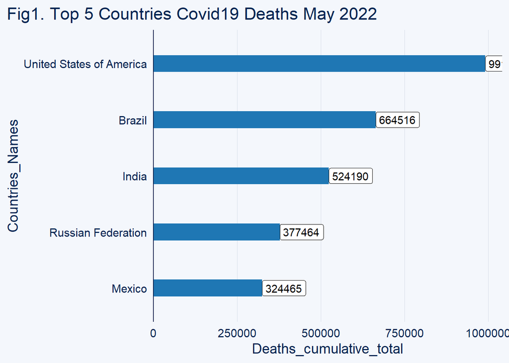

Fig1. shows the top 05 countries where many people died due to Covid19 up to May 2022 (time this report was conducted). U.S. is leading with nearly a million of deaths. It is [unprecedented] (https://www.health.com/condition/infectious-diseases/coronavirus/worst-pandemic-us-history-covid-spanish-flu). Brazil, India, Russia and Mexico are closing this list of worst Covid19 Deaths in the world. The progression on these deaths are ramping up can be view to this [blog](https://rpubs.com/amekueko/903985).

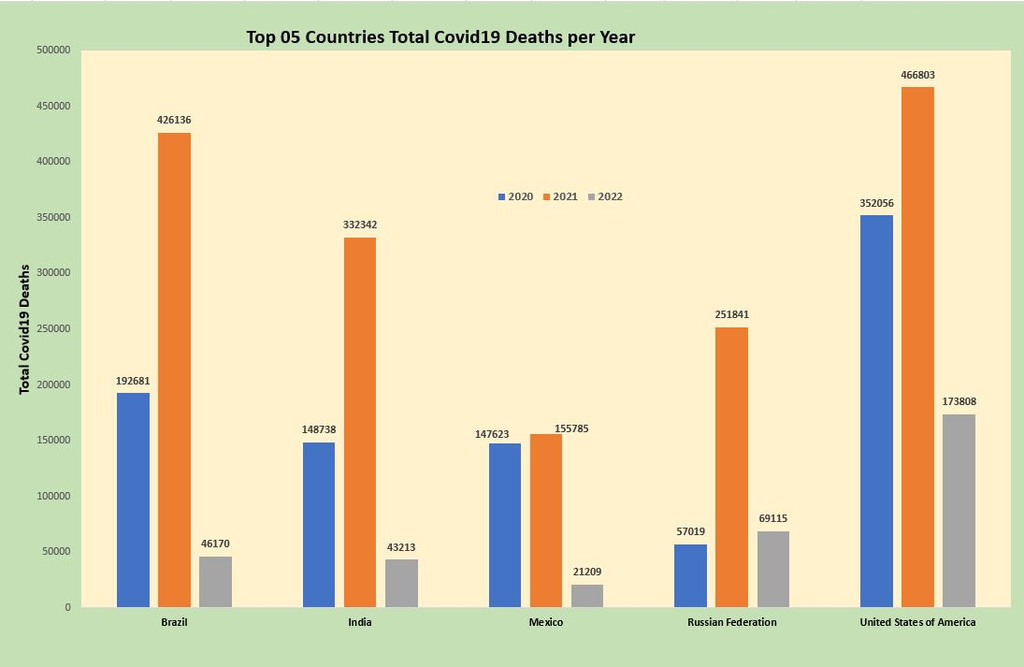

Fig2. Top 05 Countries Total Covid19 Deaths 2020-2022

In addition, Fig2 shows these 05 countries peak of Covid19 to occur in 2021. Furthermore, details on these deaths revealed that more people of age 50+ paid the highest loss with male dominating in the U.S. as of May 18, 2022 (see Fig3.&4). Covid19 deaths standalone as we said early. This disease has been throttling up and surpassing other diseases including the historical flu not mentioned on Fig5.

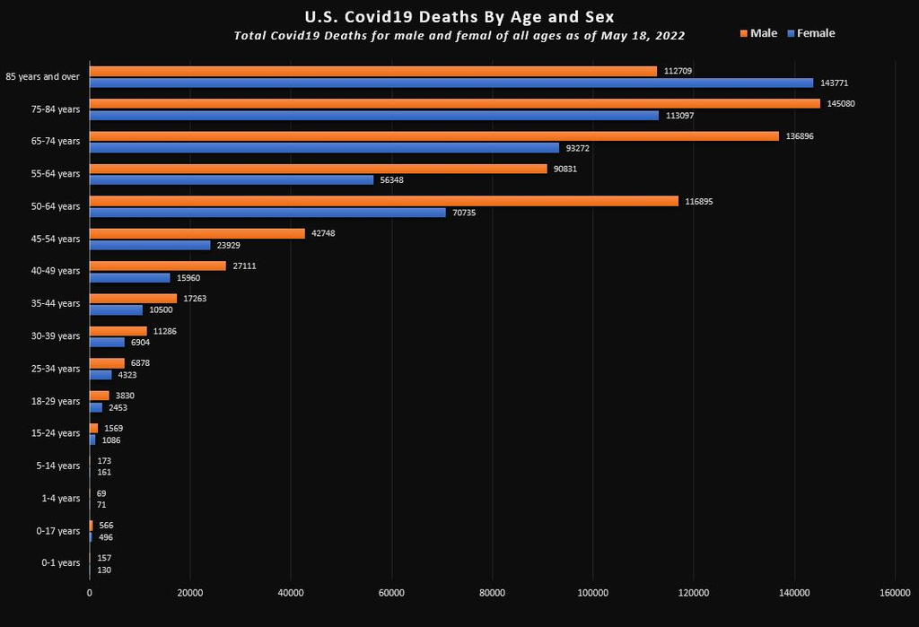

Fig3. U.S. Covid19 Deaths by Age and Sex May 2022

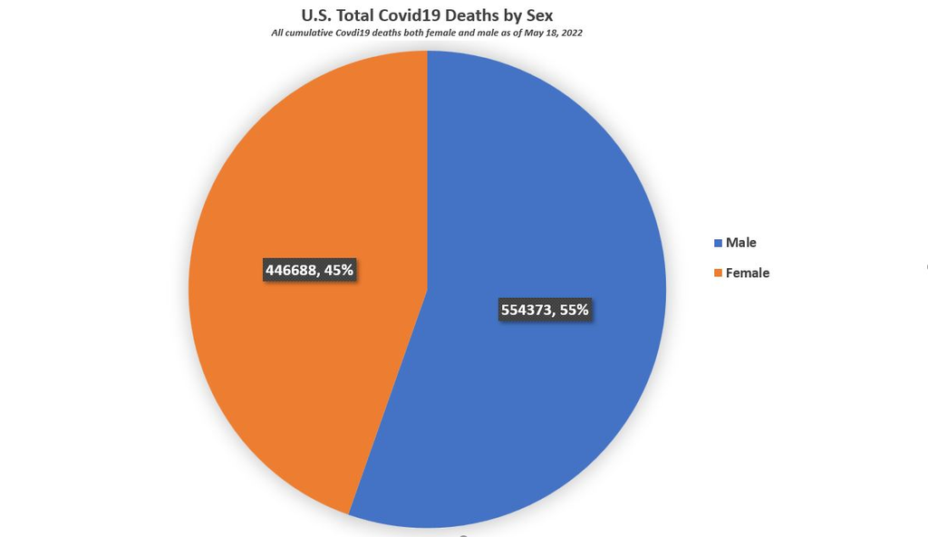

Fig4. U.S. Total Covid19 Deaths by Sex May 2022

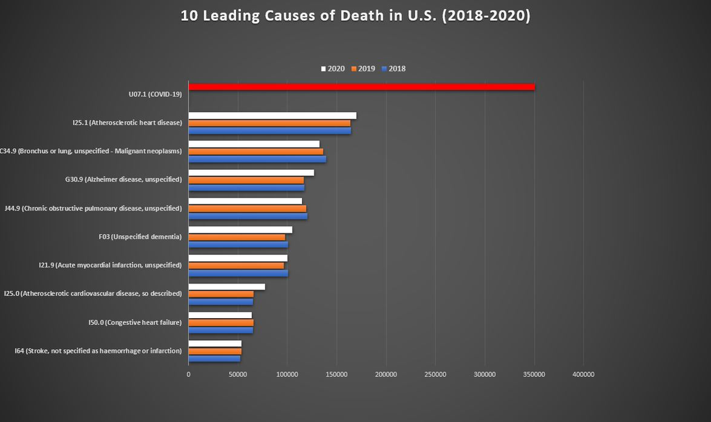

Fig5. Top 10 leading Causes of Death in U.S for 2018-2020

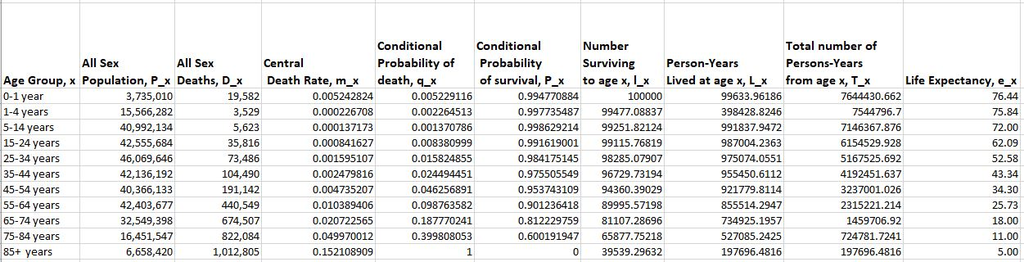

Fig6. U.S. Abridged Life Table for all sex 2020.

Based on these deaths, we calculated the mortality rate and constructed the abridged life table for 2020 (see Fig6.). Using the data of 2019, we derived and plotted the life expectancy for 2019 and 2020 for both sex (see Fig7&8).

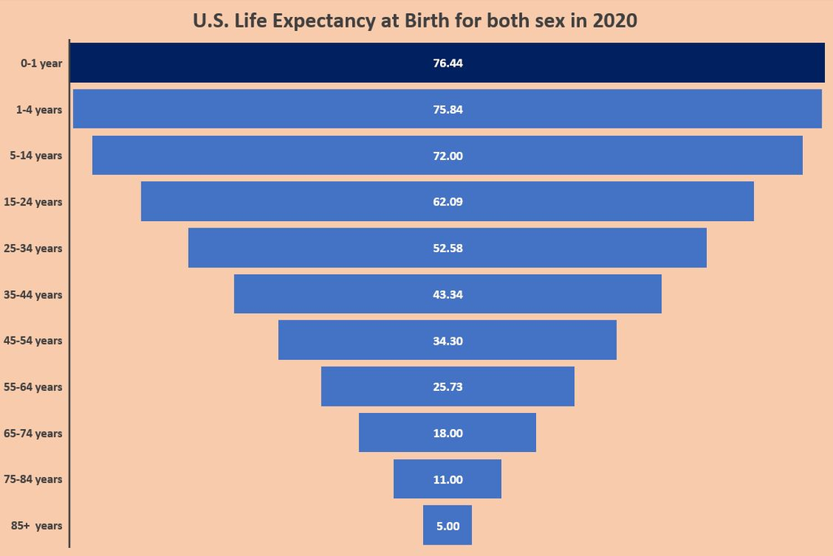

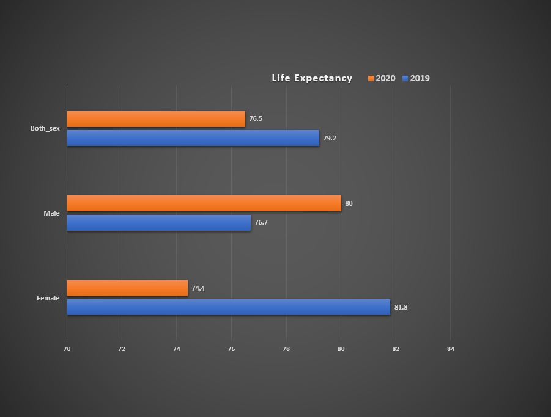

Evidences from the above charts show that Covid19 pandemic has a negative impact on the U.S. population demographics. Before Covi19 pandemic, female were expected to live longer than male and the situation flipped around during the first year of Covid19.

##Number of Children per Household

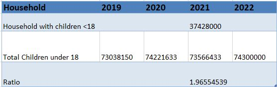

Fig9. Table for determining the number of children per household in U.S. 2019-2022

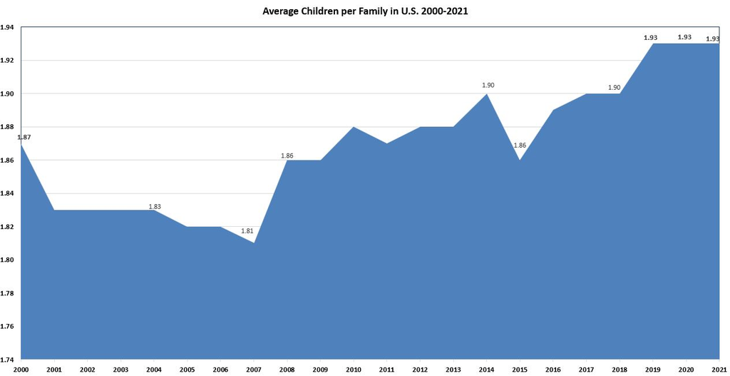

Fig10. U.S. Average Children per family 2000-2021

Fig9&10 show no effect of Covid19 pandemic on the number of children in U.S.

## Marital Status (Divorces)

were there more divorces during Covid19 pandemic (2020-2022) than 2019 in the U.S.? Were there more marriage during Covid19 pandemic (2020-2022) in the U.S.? Were there more marriage before Covid19 pandemic (<2019) in the U.S.?

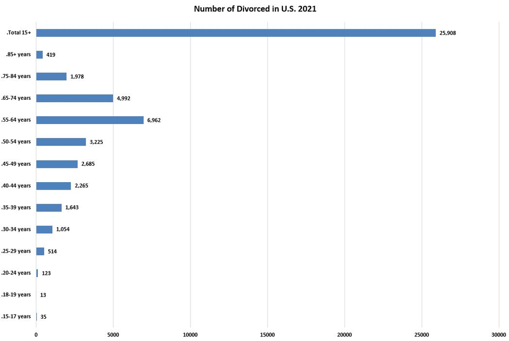

Fig11. U.S. Number of Divorces in 2021

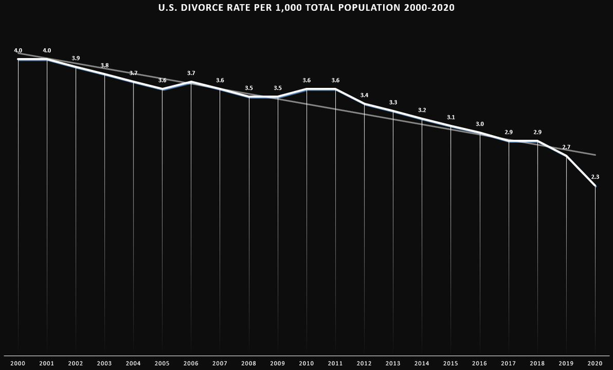

Fig12. U.S. Divorce Rate per 1000 Population 2000-2020